# Process GO data in R

### The GO.db package

The first package I will introduce is the **GO.db** package. It is maintained by the Bioconductor core team and it is frequently updated in every Bioconductor release. Thus, it always stores up-to-date data for GO and it can be treated as the standard source to read and process GO data in R. **GO.db** contains detailed information of GO terms as well as the hierarchical structure of the GO tree. The data in **GO.db** is only focused on GO terms and their relations, and it is independent to specific organisms.

First let’s load the **GO.db** package.

```r
library(GO.db)
```

#### use GO.db as a database object

**GO.db** is constructed by the low-level package **AnnotationDbi**, which defines a general database interface for storing and precessing biological annotation data. Internally the GO data is represented as an SQLite database with multiple tables. A large number of low-level functions defined in **AnnotationDbi** can be applied to the objects in **GO.db** to get customized filtering on GO data. Expericenced readers may go to the documentation of **AnnotationDbi** for more information.

Simply printing the object `GO.db` shows the basic information of the package. The two most important fields are the source file (`GOSOURCEURL`) and the date (`GOSOURCEDATE`) to build the package, which tell you the version of the GO data.

```r
GO.db
```

```
## GODb object:
## | GOSOURCENAME: Gene Ontology
## | GOSOURCEURL: http://current.geneontology.org/ontology/go-basic.obo
## | GOSOURCEDATE: 2022-07-01
## | Db type: GODb
## | package: AnnotationDbi
## | DBSCHEMA: GO_DB
## | GOEGSOURCEDATE: 2022-Sep12
## | GOEGSOURCENAME: Entrez Gene
## | GOEGSOURCEURL: ftp://ftp.ncbi.nlm.nih.gov/gene/DATA
## | DBSCHEMAVERSION: 2.1
```

```
##
## Please see: help('select') for usage information
```

`GO.db` is a database object created by **AnnotationDbi**, thus, the general method `select()` can be applied to retrieve the data by specifying a vector of “keys” which is a list of GO IDs, and a group of “columns” which are the fields where the values are retrieved. In the following code, we extract the values of `"ONTOLOGY"` and `"TERM"` for two GO IDs.

```r
select(GO.db, keys = c("GO:0000001", "GO:0000002"),
    columns = c("ONTOLOGY", "TERM"))
```

```
##         GOID ONTOLOGY                             TERM
## 1 GO:0000001       BP        mitochondrion inheritance
## 2 GO:0000002       BP mitochondrial genome maintenance
```

It can be read as “imagine `GO.db` is a table, select values in columns of ‘ONTOLOGY’ and ‘TERM’ where values in the primary column (GO_ID) are ‘GO:0000001’ and ‘GO:0000002’”.

The valid columns names can be obtained by `columns(GO.db)`.

```r
columns(GO.db)
```

```
## [1] "DEFINITION" "GOID"       "ONTOLOGY"   "TERM"
```

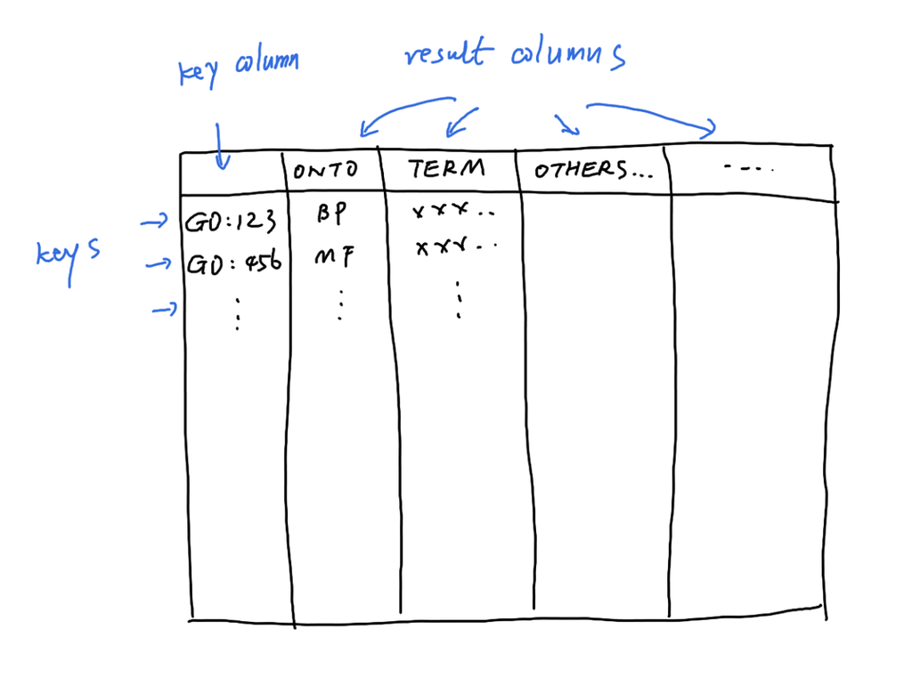

#### Objects in GO.db

However, we don’t really need to use the low-level function `select()` to retrieve the data. In **GO.db**, there are several tables that have already been compiled and can be used directly. These tables are represented as objects in the package. The following command prints all the variables that are exported in **GO.db**. Note, in the interactive R terminal, users can also see the variables by typing `GO.db::` with two continuous tabs.

```r
ls(envir = asNamespace("GO.db"))
```

```
##  [1] "GO"            "GO.db"         "GOBPANCESTOR"  "GOBPCHILDREN"
##  [5] "GOBPOFFSPRING" "GOBPPARENTS"   "GOCCANCESTOR"  "GOCCCHILDREN"
##  [9] "GOCCOFFSPRING" "GOCCPARENTS"   "GOMAPCOUNTS"   "GOMFANCESTOR"
## [13] "GOMFCHILDREN"  "GOMFOFFSPRING" "GOMFPARENTS"   "GOOBSOLETE"
## [17] "GOSYNONYM"     "GOTERM"        "GO_dbInfo"     "GO_dbconn"
## [21] "GO_dbfile"     "GO_dbschema"
```

Before I introduce the GO-related objects, I first briefly introduce the following four functions `GO_dbInfo()`, `GO_dbconn()`, `GO_dbfile()` and `GO_dbschema()` in **GO.db**. These four functions can be executed without argument. They provides information of the database, e.g., `GO_dbfile()` returns the path of the database file.

```r
GO_dbfile()
```

```
## [1] "/Users/guz/Library/R/x86_64/4.2/library/GO.db/extdata/GO.sqlite"
```

If readers are interested, they can use external tools to view the `GO.sqlite` file to see the internal representation of the database tables. However, for other readers, the internal representation of data is less important. **GO.db** provides an easy interface for processing the GO data, convert it into data frames or lists.

#### GOTERM

First let’s look at the variable `GOTERM`. It contains basic information of every individual GO term, such as GO ID, the namespace and the definition.

```r
GOTERM
```

```
## TERM map for GO (object of class "GOTermsAnnDbBimap")
```

`GOTERM` is an object of class `GOTermsAnnDbBimap`, which is a child class of a more general class `Bimap` defined in `AnnotationDbi`. Thus, many low-level functions defined in **AnnotationDbi** can be applied to `GOTERM` (see the documentation of `Bimap`). However, as suggested in the documentation of `GOTERM`, we do not need to directly work with these low-level classes, while we just simply convert it to a list.

```r
gl = as.list(GOTERM)
```

```r
length(gl)
```

```
## [1] 43559
```

We can get a single GO term by specifying the index.

```r
term = gl[[1]]  ## also gl[["GO:0000001"]]
term
```

```
## GOID: GO:0000001
## Term: mitochondrion inheritance
## Ontology: BP
## Definition: The distribution of mitochondria, including the
##     mitochondrial genome, into daughter cells after mitosis or meiosis,
##     mediated by interactions between mitochondria and the cytoskeleton.
## Synonym: mitochondrial inheritance
```

The output after printing `term` includes several fields and the corresponding values. Although `gl` is a normal list, its elements are still in a special class `GOTerms` (try typing `class(term)`). The `GOTerms` class is a simple class for storing information of individual GO terms. There are several “getter” functions to extract values in the corresponding fields. The most important functions are `GOID()`, `Term()`, `Ontology()`, and `Definition()`. Other information on the `GOTerms` function can be found from its documentation by `?GOTerms`.

```r
GOID(term)
```

```
## [1] "GO:0000001"
```

```r
Term(term)
```

```
## [1] "mitochondrion inheritance"
```

```r
Ontology(term)
```

```
## [1] "BP"
```

```r
Definition(term)
```

```
## [1] "The distribution of mitochondria, including the mitochondrial genome, into daughter cells after mitosis or meiosis, mediated by interactions between mitochondria and the cytoskeleton."
```

Then, to get the namespaces of all GO terms, we can do:

```r
ol = sapply(gl, Ontology)
head(ol)
```

```
## GO:0000001 GO:0000002 GO:0000003 GO:0000006 GO:0000007 GO:0000009
##       "BP"       "BP"       "BP"       "MF"       "MF"       "MF"
```

Besides working on individual GO terms, the getter functions can be directly applied on the global `GOTERM` object to extract information of all GO terms simultaneously.

```r
head(GOID(GOTERM))
```

```
##   GO:0000001   GO:0000002   GO:0000003   GO:0000006   GO:0000007   GO:0000009
## "GO:0000001" "GO:0000002" "GO:0000003" "GO:0000006" "GO:0000007" "GO:0000009"
```

```r
head(Ontology(GOTERM))
```

```
## GO:0000001 GO:0000002 GO:0000003 GO:0000006 GO:0000007 GO:0000009
##       "BP"       "BP"       "BP"       "MF"       "MF"       "MF"
```

Now let’s go back to the object `GOTERM`. It stores data for all GO terms, so essentially it is a list of elements in a certain format. `GOTERM` or its class `GOTermsAnnDbBimap` allows subsetting to obtain a subset of GO terms. There are two types of subset operators: single bracket `[` and double brackets `[[` and they have different behaviors.

Similar as the subset operators for list, the single bracket `[` returns a subset of data but still keeps the original format. Both numeric and character indices are allowed, but more often, character indices as GO IDs are used.

```r
# note you can also use numeric indices
GOTERM[c("GO:0000001", "GO:0000002", "GO:0000003")]
```

```
## TERM submap for GO (object of class "GOTermsAnnDbBimap")
```

So, if you want to get information of a subset of GO terms, you can do like:

```r
go_id = c("GO:0000001", "GO:0000002", "GO:0000003")
Ontology(GOTERM[go_id])
```

```
## GO:0000001 GO:0000002 GO:0000003
##       "BP"       "BP"       "BP"
```

The double-bracket operator `[[` is different. It degenerates the original format and directly extracts the element in it. Note here only a single character index is allows:

```r
# note numeric index is not allowed
GOTERM[["GO:0000001"]]
```

```
## GOID: GO:0000001
## Term: mitochondrion inheritance
## Ontology: BP
## Definition: The distribution of mitochondria, including the
##     mitochondrial genome, into daughter cells after mitosis or meiosis,
##     mediated by interactions between mitochondria and the cytoskeleton.
## Synonym: mitochondrial inheritance
```

This behaves the same as `gl[["GO::0000001"]]`.

We can calculate some simple statistics on the GO terms, such as the number of terms under each GO namespace. Directly applying `Ontology()` on `GOTERM`, it is easy to count number of GO terms in each namespace.

```r
table(Ontology(GOTERM))
```

```
##
##        BP        CC        MF universal
##     28140      4180     11238         1
```

Interestingly, besides the three namespaces `"BP"`, `"CC"` and `"MF"`, there is an additionally namespace `"universal"` that only contains one term. As mentioned before, the three GO namespaces are isolateted. However, some tools may require all GO terms are connected if the relations are represented as a graph. Thus, one pseudo “universal root term” is added as the parent of root nodes in the three namespaces. In **GO.db**, this special term has an ID `"all"`.

```r
which(Ontology(GOTERM) == "universal")
```

```
##   all
## 43559
```

```r
GOTERM[["all"]]
```

```
## GOID: all
## Term: all
## Ontology: universal
## Definition: NA
```

#### Term relations in GO.db

**GO.db** also provides variables that contains relations between GO terms. Taking biological process namespace as an example, there are the following four variables (similar for other two namespaces, but with `GOCC` and `GOMF` prefix).

- `GOBPCHILDREN`
- `GOBPPARENTS`
- `GOBPOFFSPRING`
- `GOBPANCESTOR`

`GOBPCHILDREN` and `GOBPPARENTS` contain parent-child relations. `GOBPOFFSPRING` contains all offspring terms of GO terms (i.e., all downstream terms of a term in the GO tree) and `GOBPANCESTOR` contais all ancestor terms of a GO term (i.e., all upstream terms of a term). The information in the four variables are actually redudant, e.g., all the other three objects can be constructed from `GOBPCHILDREN`. However, these pre-computated objects will save time in downstream analysis because traversing the GO tree is time-consuming.

The four variables are in the same format (objects of the `AnnDbBimap` class, also inherts from the `Bimap` class). Taking `GOBPCHILDREN` as an example, we directly convert it to a list.

```r
lt = as.list(GOBPCHILDREN)
head(lt)
```

```
## $`GO:0000001`
## [1] NA
##
## $`GO:0000002`
##      part of
## "GO:0032042"
##
## $`GO:0000003`
##          isa          isa      part of          isa          isa          isa
## "GO:0019953" "GO:0019954" "GO:0022414" "GO:0032504" "GO:0032505" "GO:0075325"
##          isa
## "GO:1990277"
##
## $`GO:0000011`
## [1] NA
##
## $`GO:0000012`
##            regulates negatively regulates positively regulates
##         "GO:1903516"         "GO:1903517"         "GO:1903518"
##                  isa                  isa
##         "GO:1903823"         "GO:1990396"
##
## $`GO:0000017`
## [1] NA
```

`lt` is a simple list of vectors where each vector are child terms of a specific GO term, e.g., `GO:0000002` has a child term `GO:0032042`. The element vectors in `lt` are also named and the names represent the relation of the child term to the parent term. When the element vector has a value `NA`, e.g. `GO::0000001`, this means the GO term is a leaf in the GO tree, and it has no child term.

Some downstream analysis, e.g., network analysis, may expect the relations to be represented as two columns. In this case, we can use the general function `toTable()` defined in **AnnotationDbi** to convert `GOBPCHILDREN` to a data frame (`toTable()` can also be applied to `GOTERM`. Readers can try to see what is the output from `toTable(GOTERM)`.).

```r
tb = toTable(GOBPCHILDREN)
head(tb)
```

```
##        go_id      go_id RelationshipType
## 1 GO:0032042 GO:0000002          part of
## 2 GO:0019953 GO:0000003              isa
## 3 GO:0019954 GO:0000003              isa
## 4 GO:0022414 GO:0000003          part of
## 5 GO:0032504 GO:0000003              isa
## 6 GO:0032505 GO:0000003              isa
```

Unfortunately, the first two columns in `tb` have the same name. A good idea is to add meaningful column names to it.

```r
colnames(tb)[1:2] = c("child", "parent")
```

Please note, the previous column names are only valid for `GOBPCHILDREN`. If it is from one of the three `GOBP*` objects, readers please inspect the output to determine proper column names for it.

With `tb`, we can calculate the fraction of different relations of GO terms.

```r
tb = toTable(GOBPCHILDREN)
table(tb[, 3])
```

```
##
##                  isa negatively regulates              part of
##                51414                 2742                 5035
## positively regulates            regulates
##                 2732                 3184
```

Note, only `GOBPPARENTS` and `GOBPANCESTOR` contain the universal root term `"all"`.

```r
lt = as.list(GOBPPARENTS)
lt[["GO:0008150"]]  # GO:0008150 is "biological process"
```

```
##   isa
## "all"
```

We can look at the distribution of the number of GO terms in each object.

1. Number of child terms. This is also the out-degree distribution if thinking the GO tree as a graph. The following plot shows the out-degree follows a power-law distribution.

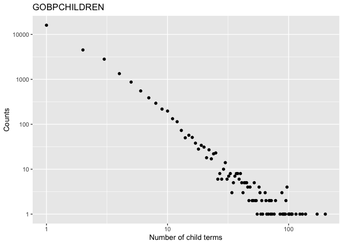

```r
lt = as.list(GOBPCHILDREN)
tb = table(sapply(lt, length))
x = as.numeric(names(tb))
y = as.vector(tb)

library(ggplot2)
ggplot(data.frame(x = x, y = y), aes(x = x, y = y)) +
    geom_point() +
    scale_x_continuous(trans='log10') +
    scale_y_continuous(trans='log10') +
    labs(x = "Number of child terms", y = "Counts") + ggtitle("GOBPCHILDREN")
```

2. Number of parent terms. The term “GO:0008150” (biological process) is removed from the analysis because it is the top node in BP namespace and it has no parent term.

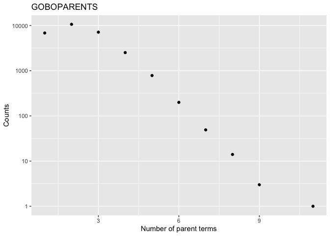

```r
lt = as.list(GOBPPARENTS)
lt = lt[names(lt) != "GO:0008150"]
tb = table(sapply(lt, length))
x = as.numeric(names(tb))
y = as.vector(tb)

ggplot(data.frame(x = x, y = y), aes(x = x, y = y)) +
    geom_point() +
    scale_y_continuous(trans='log10') +
    labs(x = "Number of parent terms", y = "Counts") + ggtitle("GOBOPARENTS")
```

3. Number of offspring terms. It also follows a power-law distribution.

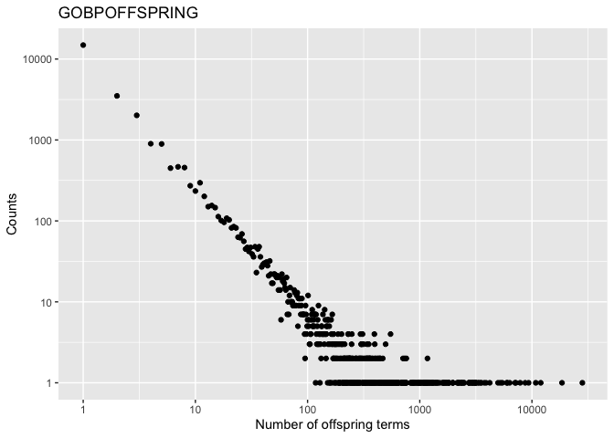

```r
lt = as.list(GOBPOFFSPRING)
tb = table(sapply(lt, length))
x = as.numeric(names(tb))
y = as.vector(tb)

ggplot(data.frame(x = x, y = y), aes(x = x, y = y)) +
    geom_point() +
    scale_x_continuous(trans='log10') +
    scale_y_continuous(trans='log10') +
    labs(x = "Number of offspring terms", y = "Counts") + ggtitle("GOBPOFFSPRING")
```

4. Number of ancestor terms. This can be approximated as from a Possion distribution.

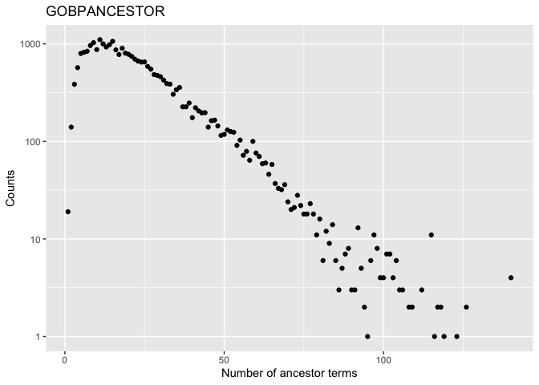

```r
lt = as.list(GOBPANCESTOR)
lt = lt[names(lt) != "GO:0008150"]
lt = lapply(lt, function(x) setdiff(x, "all"))
tb = table(sapply(lt, length))
x = as.numeric(names(tb))
y = as.vector(tb)

ggplot(data.frame(x = x, y = y), aes(x = x, y = y)) +
    geom_point() +
    scale_y_continuous(trans='log10') +
    labs(x = "Number of ancestor terms", y = "Counts") + ggtitle("GOBPANCESTOR")
```

#### Graph analysis of GO tree

Relations in `GOBPCHILDREN` or `GOBPPARENTS` can be used to construct the GO tree as a “graph” or a “netowrk” object. In the remaining part of this section, I will demonstrate some explorary analysis to show interesting attributes of the GO graph.

Remember `toTable()` returns the relations between GO terms as a data frame, thus, it can be used as “edge list” (or adjacency list). In the following code, we use **igraph** package for network analysis. The function `graph.edgelist()` construct a graph object from a two-column matrix where the first column is the source of the link and the second column is the target of the link.

```r
library(igraph)
tb = toTable(GOBPCHILDREN)
g = graph.edgelist(as.matrix(tb[, 2:1]))
g
```

```
## IGRAPH 93909b0 DN-- 28140 65107 --
## + attr: name (v/c)
## + edges from 93909b0 (vertex names):
##  [1] GO:0000002->GO:0032042 GO:0000003->GO:0019953 GO:0000003->GO:0019954
##  [4] GO:0000003->GO:0022414 GO:0000003->GO:0032504 GO:0000003->GO:0032505
##  [7] GO:0000003->GO:0075325 GO:0000003->GO:1990277 GO:0000012->GO:1903516
## [10] GO:0000012->GO:1903517 GO:0000012->GO:1903518 GO:0000012->GO:1903823
## [13] GO:0000012->GO:1990396 GO:0000018->GO:0000019 GO:0000018->GO:0000337
## [16] GO:0000018->GO:0010520 GO:0000018->GO:0010569 GO:0000018->GO:0045191
## [19] GO:0000018->GO:0045910 GO:0000018->GO:0045911 GO:0000018->GO:0061806
## [22] GO:0000018->GO:0072695 GO:0000018->GO:1903110 GO:0000019->GO:0032207
## + ... omitted several edges
```

We can extract GO term with the highest in-degree. This is the term with the largest number of parents. This value can also be get from `GOBPPARENTS`. Please note `which.max()` only returns one index of the max value, but it does not mean it is the only max value.

```r
d = degree(g, mode = "in")
d_in = d[which.max(d)]
d_in
```

```
## GO:0106110
##         11
```

```r
GOTERM[[ names(d_in) ]]
```

```
## GOID: GO:0106110
## Term: vomitoxin biosynthetic process
## Ontology: BP
## Definition: The chemical reactions and pathways resulting in the
##     formation of type B trichothecene vomitoxin, also known as
##     deoxynivalenol, a poisonous substance produced by some species of
##     fungi and predominantly occurs in grains such as wheat, barley and
##     oats.
## Synonym: deoxynivalenol biosynthetic process
## Synonym: DON biosynthetic process
## Synonym: vomitoxin anabolism
## Synonym: vomitoxin biosynthesis
## Synonym: vomitoxin formation
## Synonym: vomitoxin synthesis
```

We can calculate GO term with the highest out-degree. This is the term with the largest number of children. This value can also be get from `GOBPCHILDREN`.

```r
d = degree(g, mode = "out")
d_out = d[which.max(d)]
d_out
```

```
## GO:0048856
##        201
```

```r
GOTERM[[ names(d_out) ]]
```

```
## GOID: GO:0048856
## Term: anatomical structure development
## Ontology: BP
## Definition: The biological process whose specific outcome is the
##     progression of an anatomical structure from an initial condition to
##     its mature state. This process begins with the formation of the
##     structure and ends with the mature structure, whatever form that
##     may be including its natural destruction. An anatomical structure
##     is any biological entity that occupies space and is distinguished
##     from its surroundings. Anatomical structures can be macroscopic
##     such as a carpel, or microscopic such as an acrosome.
## Synonym: development of an anatomical structure
```

We can explore some long-disatnce attributes, such as the distance from the root term to every term in the namespace. The distance can be thought as the depth of a term in the GO tree.

```r
dist = distances(g, v = "GO:0008150", mode = "out")
table(dist)
```

```
## dist
##    0    1    2    3    4    5    6    7    8    9   10   11
##    1   24  519 3488 7419 8095 5180 2429  802  149   29    5
```

We can also extract the longest path from the root term to the leaf terms.

```r
d = degree(g, mode = "out")
leave = names(d[d == 0])
sp = shortest_paths(g, from = "GO:0008150", to = leave, mode = "out")
i = which.max(sapply(sp$vpath, length))
path = sp$vpath[[i]]
Term(GOTERM[names(path)])
```

```
##                                                                                         GO:0008150
##                                                                               "biological_process"
##                                                                                         GO:0008152
##                                                                                "metabolic process"
##                                                                                         GO:0006807
##                                                              "nitrogen compound metabolic process"
##                                                                                         GO:0051173
##                                       "positive regulation of nitrogen compound metabolic process"
##                                                                                         GO:0051247
##                                                 "positive regulation of protein metabolic process"
##                                                                                         GO:0045862
##                                                               "positive regulation of proteolysis"
##                                                                                         GO:0010952
##                                                        "positive regulation of peptidase activity"
##                                                                                         GO:0010950
##                                                    "positive regulation of endopeptidase activity"
##                                                                                         GO:2001056
##                                      "positive regulation of cysteine-type endopeptidase activity"
##                                                                                         GO:0043280
##        "positive regulation of cysteine-type endopeptidase activity involved in apoptotic process"
##                                                                                         GO:0006919
##                 "activation of cysteine-type endopeptidase activity involved in apoptotic process"
##                                                                                         GO:0008635
## "activation of cysteine-type endopeptidase activity involved in apoptotic process by cytochrome c"
```

### Link GO terms to genes

As introduced in the previous section, **GO.db** only contains information for GO terms. GO also provides gene annotated to GO terms, by manual curation or computation prediction. Such annotations are represented as mappings between GO IDs and gene IDs from external databases, which are usually synchronized between major public databases such NCBI.

#### org.Hs.eg.db

To obtains genes in each GO term in R, Bioconductor provides a family of packages with name of **org.*.db**. Let’s take human for example, the corresponding package is **org.Hs.eg.db**. **org.Hs.eg.db** provides a standard way to provide mappings from Entrez gene IDs to a variaty of other databases.

```r
library(org.Hs.eg.db)
```

In this package, there are two database table objects for mapping between GO IDs and genes:

- `org.Hs.egGO2EG`
- `org.Hs.egGO2ALLEGS`

Again, `org.Hs.egGO2ALLEGS` is a database object. There are two ways to obtain gene annotations to GO terms. The first is to convert `org.Hs.egGO2ALLEGS` to a list of gene vectors.

```r
lt = as.list(org.Hs.egGO2ALLEGS)
lt[3:4] # lt[[2]] is too long to print
```

```
## $`GO:0000012`
##         IGI         IDA         IDA         IDA         NAS         IDA
##       "142"      "1161"      "2074"      "3981"      "7014"      "7141"
##         IEA         IGI         IMP         IMP         IBA         IDA
##      "7515"      "7515"      "7515"     "23411"     "54840"     "54840"
##         IBA         IDA         IMP         IMP         IEA
##     "55775"     "55775"     "55775"    "200558" "100133315"
##
## $`GO:0000017`
##    IDA    IMP    ISS    IDA
## "6523" "6523" "6523" "6524"
```

In this case, each element vector actually is a GO gene set. Note here the genes are in Entrez IDs, which are digits but in character mode. Node this is important to save the Gene IDs explicitely as characters to get rid of potential error due to indexing. We will emphasize it again in later text.

The gene IDs have names. They are evidence of annotating genes to GO terms.

`org.Hs.egGO2ALLEGS` is a database object (also inherts from the `Bimap` class), thus `toTable()` can be directly applied to convert it as a table.

```r
tb = toTable(org.Hs.egGO2ALLEGS)
head(tb)
```

```
##   gene_id      go_id Evidence Ontology
## 1       1 GO:0008150       ND       BP
## 2       2 GO:0000003      IEA       BP
## 3       2 GO:0001553      IEA       BP
## 4       2 GO:0001867      IDA       BP
## 5       2 GO:0001868      IDA       BP
## 6       2 GO:0001869      IDA       BP
```

Now there is an additional column `"Ontology"`. This is convinient because `org.Hs.egGO2ALLEGS` contains GO terms from the three namespaces and the `as.list()` cannot distinguish the different namespaces.

With `tb`, we can look at the distribution of number of genes in GO gene sets. It approximately follows a power-law distribution.

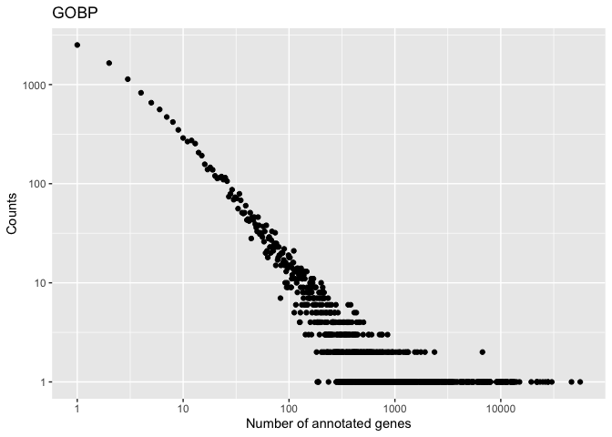

```r
tb = tb[tb$Ontology == "BP", ]
t1 = table(table(tb$go_id))
x1 = as.numeric(names(t1))
y1 = as.vector(t1)
ggplot(data.frame(x = x1, y = y1), aes(x = x, y = y)) +
    geom_point() +
    scale_x_continuous(trans='log10') +
    scale_y_continuous(trans='log10') +
    labs(x = "Number of annotated genes", y = "Counts") + ggtitle("GOBP")
```

And the distribution of number of GO gene sets that a gene is in.

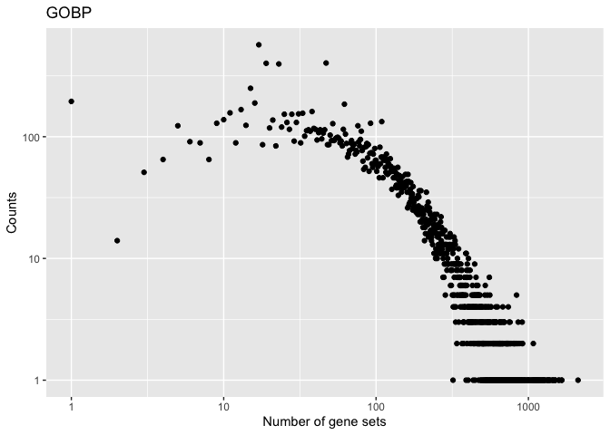

```r
t2 = table(table(tb$gene_id))
x2 = as.numeric(names(t2))
y2 = as.vector(t2)
ggplot(data.frame(x = x2, y = y2), aes(x = x, y = y)) +
    geom_point() +
    scale_x_continuous(trans='log10') +
    scale_y_continuous(trans='log10') +
    labs(x = "Number of gene sets", y = "Counts") + ggtitle("GOBP")
```

Biocondutor core team maintaines **org.*.db** for 18 organisms

| Package | Organism | Package | Organism |
| --- | --- | --- | --- |
| `org.Hs.eg.db` | Human | `org.Ss.eg.db` | Pig |
| `org.Mm.eg.db` | Mouse | `org.Gg.eg.db` | Chicken |
| `org.Rn.eg.db` | Rat | `org.Mmu.eg.db` | Rhesus monkey |
| `org.Dm.eg.db` | Fruit fly | `org.Cf.eg.db` | Canine |
| `org.At.tair.db` | Arabidopsis | `org.EcK12.eg.db` | E coli strain K12 |
| `org.Sc.sgd.db` | Yeast | `org.Xl.eg.db` | African clawed frog |
| `org.Dr.eg.db` | Zebrafish | `org.Ag.eg.db` | Malaria mosquito |
| `org.Ce.eg.db` | Nematode | `org.Pt.eg.db` | Chimpanzee |
| `org.Bt.eg.db` | Bovine | `org.EcSakai.eg.db` | E coli strain Sakai |